# Modeling and Simulation in Python

```python
# Configure Jupyter so figures appear in the notebook
%matplotlib inline

# Configure Jupyter to display the assigned value after an assignment
%config InteractiveShell.ast_node_interactivity='last_expr_or_assign'

# import functions from the modsim.py module
from modsim import *
```

## SIR Implementation

We'll use a `State` object to represent the number (or fraction) of people in each compartment. Assume we have 1 infected in a class of 90 students.

```python
init = State(S=89, I=1, R=0)
```

|  | values |
| --- | --- |
| S | 89 |
| I | 1 |
| R | 0 |

To convert from number of people to fractions, we divide through by the total.

```python
init /= sum(init)
```

|  | values |
| --- | --- |
| S | 0.988889 |
| I | 0.011111 |
| R | 0.000000 |

`make_system` creates a `System` object with the given parameters. Assume semester length is 14 weeks.

```python
def make_system(beta, gamma):
    """Make a system object for the SIR model.

    beta: contact rate in days
    gamma: recovery rate in days

    returns: System object
    """
    init = State(S=89, I=1, R=0)
    init /= sum(init)

    t0 = 0
    t_end = 7 * 14

    return System(init=init, t0=t0, t_end=t_end,
                  beta=beta, gamma=gamma)
```

Here's an example with hypothetical values for `beta` and `gamma`.

```python
tc = 3      # time between contacts in days
tr = 4      # recovery time in days

beta = 1 / tc      # contact rate in per day
gamma = 1 / tr     # recovery rate in per day

system = make_system(beta, gamma)
```

|  | values |
| --- | --- |
| init | S 0.988889 I 0.011111 R 0.000000 dtyp... |
| t0 | 0 |
| t_end | 98 |
| beta | 0.333333 |
| gamma | 0.25 |

```python
def update_func(state, t, system):
    """Update the SIR model.

    state: State with variables S, I, R
    t: time step
    system: System with beta and gamma

    returns: State object
    """
    s, i, r = state

    infected = system.beta * i * s
    recovered = system.gamma * i

    s -= infected
    i += infected - recovered
    r += recovered

    return State(S=s, I=i, R=r)
```

To run a single time step, we call it like this:

```python
state = update_func(init, 0, system)
```

|  | values |
| --- | --- |
| S | 0.985226 |
| I | 0.011996 |
| R | 0.002778 |

Now we can run a simulation by calling the update function for each time step.

```python
def run_simulation(system, update_func):
    """Runs a simulation of the system.

    system: System object
    update_func: function that updates state

    returns: State object for final state
    """
    state = system.init

    for t in linrange(system.t0, system.t_end):
        state = update_func(state, t, system)

    return state
```

The result is the state of the system at `t_end`

```python
run_simulation(system, update_func)
```

|  | values |
| --- | --- |
| S | 0.520568 |
| I | 0.000666 |
| R | 0.478766 |

Suppose the time between contacts is 4 days and the recovery time is 5 days. After 14 weeks, how many students, total, have been infected?

```python
tc = 4      # time between contacts in days
tr = 5      # recovery time in days

beta = 1 / tc      # contact rate in per day
gamma = 1 / tr     # recovery rate in per day

system = make_system(beta, gamma)
```

|  | values |
| --- | --- |
| init | S 0.988889 I 0.011111 R 0.000000 dtyp... |
| t0 | 0 |
| t_end | 98 |
| beta | 0.25 |
| gamma | 0.2 |

```python
state = update_func(init, 0, system)
```

|  | values |
| --- | --- |
| S | 0.986142 |
| I | 0.011636 |
| R | 0.002222 |

```python
run_simulation(system, update_func)
```

|  | values |
| --- | --- |
| S | 0.610171 |
| I | 0.004672 |
| R | 0.385157 |

As we can see from the simulation above, about 40 percent of the population was infected after 14 weeks. The amount of susceptible people went from roughly 0.98 to 0.61.

### Using TimeSeries objects

The previous `run_simulation` only returns the **final** state, but we might want to see how the state changes over time! If we want to store the state of the system at **each time step**, we can use one `TimeSeries` object for each state variable.

```python
def run_simulation(system, update_func):
    """Runs a simulation of the system.

    Add three Series objects to the System: S, I, R

    system: System object
    update_func: function that updates state
    """
    S = TimeSeries()
    I = TimeSeries()
    R = TimeSeries()

    state = system.init
    t0 = system.t0
    S[t0], I[t0], R[t0] = state

    for t in linrange(system.t0, system.t_end):
        state = update_func(state, t, system)
        S[t+1], I[t+1], R[t+1] = state

    return S, I, R
```

Here's how we call it

```python
tc = 3      # time between contacts in days
tr = 4      # recovery time in days

beta = 1 / tc      # contact rate in per day
gamma = 1 / tr     # recovery rate in per day

system = make_system(beta, gamma)
S, I, R = run_simulation(system, update_func)
```

And then we can plot the results

```python
def plot_results(S, I, R):
    """Plot the results of a SIR model.

    S: TimeSeries
    I: TimeSeries
    R: TimeSeries
    """
    plot(S, '--', label='Susceptible')
    plot(I, '-', label='Infected')
    plot(R, ':', label='Recovered')
    decorate(xlabel='Time (days)',
             ylabel='Fraction of population')
```

Here's what they look like.

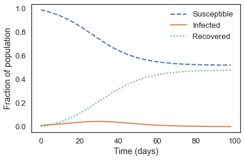

```python
plot_results(S, I, R)
```

### Using a DataFrame

Instead of making **three** `TimeSeries` objects, we can use **one** `DataFrame`. We have to use `row` to selects rows, rather than columns. But then Pandas does the right thing, matching up the state variables with the columns of the `DataFrame`.

```python
system.init.index
fr = TimeFrame(columns=system.init.index)
fr.row[0]=system.init
fr
```

|  | S | I | R |
| --- | --- | --- | --- |
| 0 | 0.988889 | 0.011111 | 0.0 |

When you store the `state` variables in the frame, the names of the `state` variables have to match the columns of `frame` - thus remember to set the coulmns using the `init` index (which is S, I, R)

```python
def run_simulation(system, update_func):
    """Runs a simulation of the system.

    system: System object
    update_func: function that updates state

    returns: TimeFrame
    """
    frame = TimeFrame(columns=system.init.index)
    frame.row[system.t0] = system.init

    for t in linrange(system.t0, system.t_end):
        frame.row[t+1] = update_func(frame.row[t], t, system)

    return frame
```

Here's how we run it, and what the result looks like.

```python
tc = 3      # time between contacts in days
tr = 4      # recovery time in days

beta = 1 / tc      # contact rate in per day
gamma = 1 / tr     # recovery rate in per day

system = make_system(beta, gamma)
results = run_simulation(system, update_func)
results.head()
```

|  | S | I | R |
| --- | --- | --- | --- |
| 0 | 0.988889 | 0.011111 | 0.000000 |
| 1 | 0.985226 | 0.011996 | 0.002778 |
| 2 | 0.981287 | 0.012936 | 0.005777 |
| 3 | 0.977055 | 0.013934 | 0.009011 |
| 4 | 0.972517 | 0.014988 | 0.012494 |

We can extract the results and plot them.

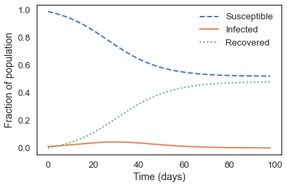

```python
plot_results(results.S, results.I, results.R)
```

```python
results[0:60]
```

|  | S | I | R |
| --- | --- | --- | --- |
| 0 | 0.988889 | 0.011111 | 0.000000 |
| 1 | 0.985226 | 0.011996 | 0.002778 |
| 2 | 0.981287 | 0.012936 | 0.005777 |
| 3 | 0.977055 | 0.013934 | 0.009011 |
| 4 | 0.972517 | 0.014988 | 0.012494 |
| 5 | 0.967658 | 0.016100 | 0.016241 |
| 6 | 0.962465 | 0.017268 | 0.020266 |
| 7 | 0.956925 | 0.018491 | 0.024584 |
| 8 | 0.951027 | 0.019767 | 0.029206 |
| 9 | 0.944761 | 0.021091 | 0.034148 |
| 10 | 0.938119 | 0.022460 | 0.039421 |
| 11 | 0.931095 | 0.023869 | 0.045036 |
| 12 | 0.923687 | 0.025310 | 0.051003 |
| 13 | 0.915895 | 0.026775 | 0.057330 |
| 14 | 0.907720 | 0.028256 | 0.064024 |
| 15 | 0.899171 | 0.029741 | 0.071088 |
| 16 | 0.890257 | 0.031220 | 0.078523 |
| 17 | 0.880992 | 0.032680 | 0.086328 |
| 18 | 0.871395 | 0.034106 | 0.094498 |
| 19 | 0.861489 | 0.035487 | 0.103025 |
| 20 | 0.851298 | 0.036805 | 0.111897 |
| 21 | 0.840854 | 0.038048 | 0.121098 |
| 22 | 0.830190 | 0.039200 | 0.130610 |
| 23 | 0.819342 | 0.040248 | 0.140410 |
| 24 | 0.808349 | 0.041179 | 0.150472 |
| 25 | 0.797254 | 0.041979 | 0.160767 |
| 26 | 0.786098 | 0.042641 | 0.171262 |
| 27 | 0.774925 | 0.043154 | 0.181922 |
| 28 | 0.763778 | 0.043512 | 0.192710 |
| 29 | 0.752700 | 0.043712 | 0.203588 |
| 30 | 0.741732 | 0.043751 | 0.214516 |
| 31 | 0.730915 | 0.043631 | 0.225454 |
| 32 | 0.720285 | 0.043353 | 0.236362 |
| 33 | 0.709876 | 0.042924 | 0.247200 |
| 34 | 0.699719 | 0.042350 | 0.257931 |
| 35 | 0.689841 | 0.041640 | 0.268519 |
| 36 | 0.680266 | 0.040805 | 0.278929 |
| 37 | 0.671014 | 0.039857 | 0.289130 |
| 38 | 0.662099 | 0.038807 | 0.299094 |
| 39 | 0.653534 | 0.037670 | 0.308796 |
| 40 | 0.645328 | 0.036459 | 0.318213 |
| 41 | 0.637485 | 0.035187 | 0.327328 |
| 42 | 0.630008 | 0.033867 | 0.336125 |
| 43 | 0.622896 | 0.032512 | 0.344591 |
| 44 | 0.616146 | 0.031135 | 0.352719 |
| 45 | 0.609751 | 0.029746 | 0.360503 |
| 46 | 0.603705 | 0.028355 | 0.367940 |
| 47 | 0.597999 | 0.026972 | 0.375028 |
| 48 | 0.592623 | 0.025606 | 0.381772 |
| 49 | 0.587564 | 0.024263 | 0.388173 |
| 50 | 0.582813 | 0.022949 | 0.394239 |
| 51 | 0.578354 | 0.021670 | 0.399976 |
| 52 | 0.574177 | 0.020430 | 0.405393 |
| 53 | 0.570266 | 0.019233 | 0.410501 |
| 54 | 0.566610 | 0.018080 | 0.415309 |
| 55 | 0.563196 | 0.016975 | 0.419829 |
| 56 | 0.560009 | 0.015918 | 0.424073 |
| 57 | 0.557037 | 0.014910 | 0.428053 |
| 58 | 0.554269 | 0.013951 | 0.431780 |
| 59 | 0.551691 | 0.013041 | 0.435268 |

Suppose the time between contacts is 4 days and the recovery time is 5 days. Simulate this scenario for 14 weeks and plot the results.

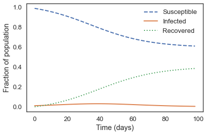

```python
tc = 4      # time between contacts in days
tr = 5      # recovery time in days

beta = 1 / tc      # contact rate in per day
gamma = 1 / tr     # recovery rate in per day

system = make_system(beta, gamma)
results = run_simulation(system, update_func)

plot_results(results.S, results.I, results.R)
```

```python
results[0:60]
```

|  | S | I | R |
| --- | --- | --- | --- |
| 0 | 0.988889 | 0.011111 | 0.000000 |
| 1 | 0.986142 | 0.011636 | 0.002222 |
| 2 | 0.983273 | 0.012177 | 0.004549 |
| 3 | 0.980280 | 0.012735 | 0.006985 |
| 4 | 0.977159 | 0.013309 | 0.009532 |
| 5 | 0.973908 | 0.013899 | 0.012194 |
| 6 | 0.970524 | 0.014503 | 0.014973 |
| 7 | 0.967005 | 0.015121 | 0.017874 |
| 8 | 0.963349 | 0.015753 | 0.020898 |
| 9 | 0.959555 | 0.016396 | 0.024049 |
| 10 | 0.955622 | 0.017050 | 0.027328 |
| 11 | 0.951549 | 0.017713 | 0.030738 |
| 12 | 0.947335 | 0.018384 | 0.034281 |
| 13 | 0.942981 | 0.019061 | 0.037957 |
| 14 | 0.938488 | 0.019743 | 0.041770 |
| 15 | 0.933855 | 0.020426 | 0.045718 |
| 16 | 0.929087 | 0.021110 | 0.049804 |
| 17 | 0.924183 | 0.021791 | 0.054025 |
| 18 | 0.919149 | 0.022468 | 0.058384 |
| 19 | 0.913986 | 0.023137 | 0.062877 |
| 20 | 0.908699 | 0.023796 | 0.067505 |
| 21 | 0.903293 | 0.024443 | 0.072264 |
| 22 | 0.897774 | 0.025074 | 0.077152 |
| 23 | 0.892146 | 0.025687 | 0.082167 |
| 24 | 0.886417 | 0.026279 | 0.087305 |
| 25 | 0.880593 | 0.026846 | 0.092560 |
| 26 | 0.874683 | 0.027387 | 0.097930 |
| 27 | 0.868694 | 0.027899 | 0.103407 |
| 28 | 0.862635 | 0.028378 | 0.108987 |
| 29 | 0.856515 | 0.028822 | 0.114662 |
| 30 | 0.850344 | 0.029229 | 0.120427 |
| 31 | 0.844130 | 0.029597 | 0.126273 |
| 32 | 0.837884 | 0.029924 | 0.132192 |
| 33 | 0.831616 | 0.030207 | 0.138177 |
| 34 | 0.825336 | 0.030446 | 0.144218 |
| 35 | 0.819054 | 0.030639 | 0.150308 |
| 36 | 0.812780 | 0.030785 | 0.156435 |
| 37 | 0.806525 | 0.030883 | 0.162592 |
| 38 | 0.800298 | 0.030933 | 0.168769 |
| 39 | 0.794109 | 0.030936 | 0.174956 |
| 40 | 0.787967 | 0.030890 | 0.181143 |
| 41 | 0.781882 | 0.030797 | 0.187321 |
| 42 | 0.775862 | 0.030658 | 0.193480 |
| 43 | 0.769915 | 0.030473 | 0.199612 |
| 44 | 0.764050 | 0.030244 | 0.205706 |
| 45 | 0.758273 | 0.029972 | 0.211755 |
| 46 | 0.752591 | 0.029659 | 0.217749 |
| 47 | 0.747011 | 0.029308 | 0.223681 |
| 48 | 0.741538 | 0.028919 | 0.229543 |
| 49 | 0.736177 | 0.028497 | 0.235327 |
| 50 | 0.730932 | 0.028042 | 0.241026 |
| 51 | 0.725808 | 0.027558 | 0.246634 |
| 52 | 0.720807 | 0.027047 | 0.252146 |
| 53 | 0.715934 | 0.026511 | 0.257555 |
| 54 | 0.711189 | 0.025954 | 0.262857 |
| 55 | 0.706574 | 0.025378 | 0.268048 |
| 56 | 0.702091 | 0.024785 | 0.273124 |
| 57 | 0.697741 | 0.024178 | 0.278081 |
| 58 | 0.693523 | 0.023560 | 0.282917 |
| 59 | 0.689438 | 0.022933 | 0.287629 |